# Illustrating use of pixelated thigh utilities

W. Bauer

December 16, 2015

```r
source("../R/utilities.R")
source("../R/pixelated_thigh_utils.R")
```

Whole thigh pixelated images with various pixel sizes are in the `data` directory. They are `csv` files which can be read with standard R functions, `read.csv` to read as an R `data.frame` and `as.matrix` to convert from `data.frame` to matrix.

```r
img <- as.matrix(read.csv("../data/whole_thigh_32.csv"))
```

The pixels of the image are labeled with integers indicating tissue types. Ordinarily, these would be converted to slowness values, but that is unnecessary for present purposes. I’ve found two suitable rectangular sections by trial and error. They can be superimposed on the image as follows.

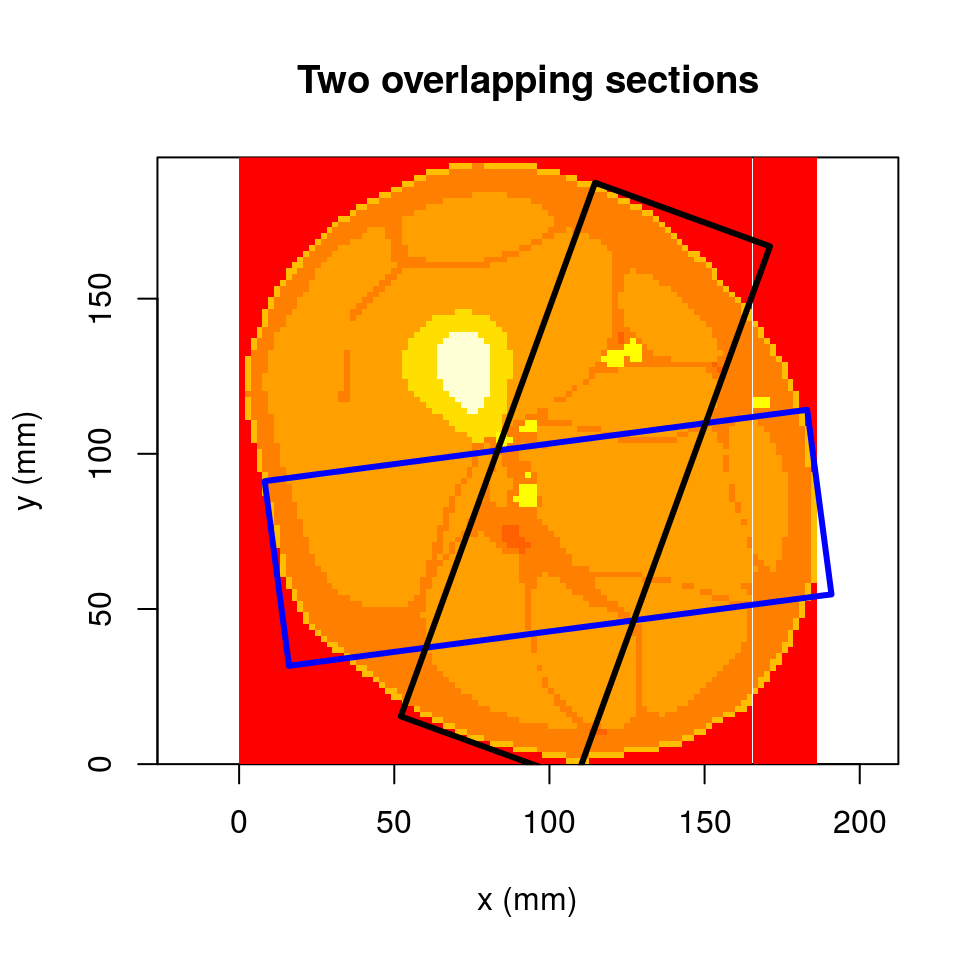

```r
gridsize <- .47*128/32
displayImage(img, gridsize, main="Two overlapping sections")
# Compute first rectangular section
sectionA <- minRect(img, gridsize, center=c(100, 73), angle_in_radians=pi/24, height=60)
# Display it
polygon(sectionA, lwd=3, border="blue")
# Compute second rectangular section
sectionB <- minRect(img, gridsize, center=c(105, 73), angle_in_radians=pi/2-pi/9, height=60)
# Display it
polygon(sectionB, lwd=3, border="black")
```

```r
# Compute transducer positions for each rectangular section
probesA <- probePos(32, sectionA)
probesB <- probePos(32, sectionB)
# Inspect probesA
str(probesA)
```

```
## List of 2
##  $ probe1: num [1:32, 1:2] 8.37 8.61 8.86 9.1 9.35 ...
##  $ probe2: num [1:32, 1:2] 191 191 190 190 190 ...
```

As can be seen, `probesA` is a list of two 32x2 matrices named probe1 and probe2 respectively. The rows of these matrices represent transducer positions. These can be superimposed on an image using the standard R function, `points`. Since 32 probes would be cluttered, I only plot every 4th one.

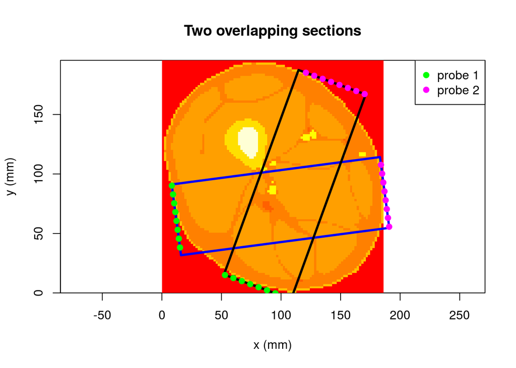

```r
displayImage(img, gridsize, main="Two overlapping sections")
polygon(sectionA, lwd=3, border="blue")
polygon(sectionB, lwd=3, border="black")
idx <- seq(1, 32, by=4)
points(probesA$probe1[idx,1], probesA$probe1[idx,2], pch=19, col="green")
points(probesA$probe2[idx,1], probesA$probe2[idx,2], pch=19, col="magenta")
points(probesB$probe1[idx,1], probesB$probe1[idx,2], pch=19, col="green")
points(probesB$probe2[idx,1], probesB$probe2[idx,2], pch=19, col="magenta")
legend('topright', c("probe 1", "probe 2"), pch=19, col=c("green", "magenta"))
```